# rep

## Analysis of Customer Lifetime Value by Segment

This document details the process,findings and recommendations obtained after analysing business data for a credit card company. Customer value can be defined as the total amount of income a company can expect to get from a client as long as he/she remains a client. For this analysis the following formula was used to calculate Customer Lifetime Value(CLV).

$ CLV = (Customer ~Value~ \times Average~ Customer ~Lifespan) - Acquistion ~Cost(500) $

$ Customer ~Value = Average~TransactionValue~ \times~ Average ~Transaction frequency$

$ Average~ Transaction~ Value = Total~ transaction ~value \times 0.01 $

To obtain the customer value,the average transaction value was multiplied by the average transaction frequency rate. The average transaction value for each customer was obtained by multiplying the total transaction value of the customer over the year by 1%.

To obtain the average transaction frequency, the following formula was used:

$ Average ~ Transaction ~frequency = \frac{Total ~ number ~ of ~ transactions}{~Total ~number ~of ~businesses} $

The Average Customer Lifespan was calculated as follows:

$ Average ~ Customer ~ Lifespan = \frac{Sum~ of~ Customer ~Lifespans(Days)}{Total ~number ~of ~customers} $

The segments used were the industry Subgroups and the number of businesses per industry was as follows:

| Industry | Count |
| --- | --- |
| Food, Drink & Hospitality | 244 |
| Retail | 171 |
| Healthcare, beauty & fitness | 67 |
| Professional services | 62 |
| Home & repair | 62 |
| Leisure & entertainment | 37 |
| Travel & tourism | 34 |
| Online | 33 |
| Personal services | 7 |
| Transportation | 5 |

## Results and Findings

Aggregating the Customer Lifetime Value Results by Industry produced the following results:

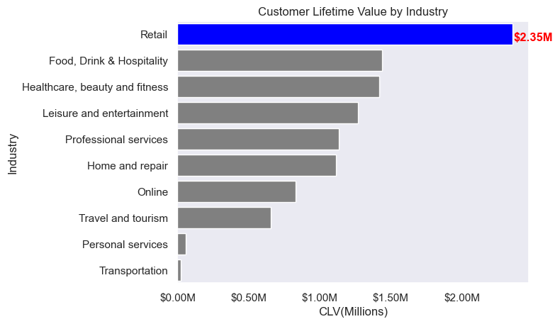

The results show that:

1. The Retail Industry has the Highest Customer Lifetime Value with a ClV value of around $2.35M.
2. The food,drink and Hospitality Industry and Health Care Industry came second with a CLV of around 1.4M.
3. The transportation Industry has the Lowest CLV with a value of around 0.024M Dollars.

A further analysis of the Retail's Industry CLV Revealed that more than 80% of the CLV came from two Cities:Johannesburg and Capetown with Capetown accounting for more than 60% of the Retail Industry Customer Lifetime Value.

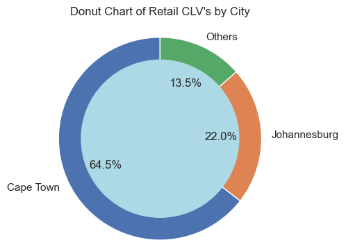

### Analysing the Churn Rate by Industry

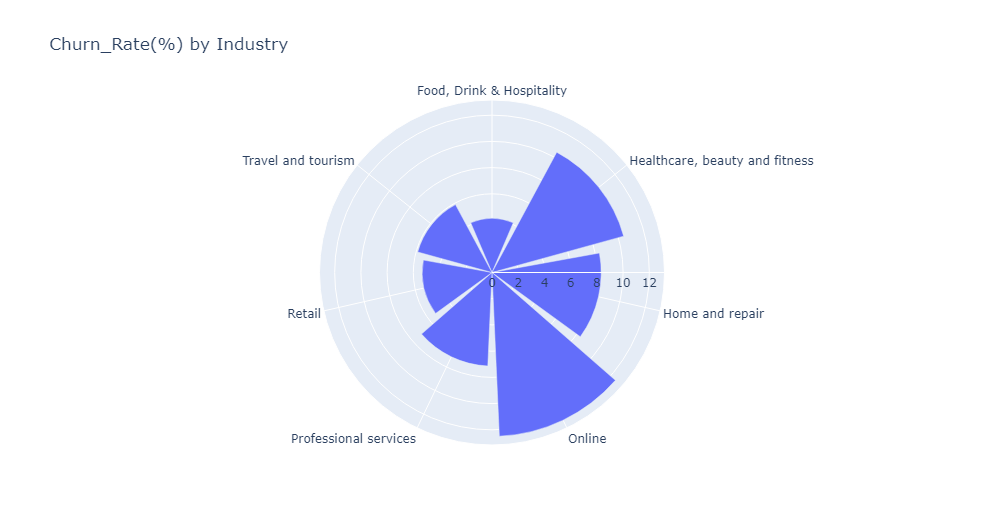

The churn rate was calculated by considering a customer to have churned if the interval between the two most recent transactions was more than 90 days(3months). The results reveal that:

1. The transportation, Leisure& Entertainment and Personal Services had no churn over the year,2015
2. The online industry has the highest churn rate approximately 12.5%, followed by the HealthCare, Beauty and fitness Industry with a churn rate of 10.42%

#### Mean Processing time

To obtain the weekly mean processing time, I used the transaction created column of the transaction subset to get the week number of the transaction using the iso calendar. I then grouped the processing times by week to obtain the mean processing time for each week of the year. I got the mean of this weekly means to get the average mean processing time per week. This value was 21.14 seconds. I created a line graph to see in which weeks of the year the mean processing time was higher than normal.

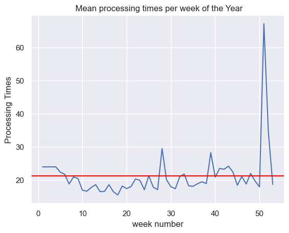

It is noteworthy to consider that transactions processing times are significantly higher during the end of the year between week 50 and 54.

#### Transaction Approval Rate

I obtained the transaction approval rate by checking the proportions of each transaction state of the transaction subset dataset. The results were as follows:

| Transaction_state | Proportion |
| --- | --- |
| Approved | 79.69% |
| Error | 10.53% |
| Aborted | 7.60% |
| Declined | 1.71% |
| Refunded | 0.47% |
| Created | 0.01% |

The credit card company has a transaction approval rate of 79.69%.

#### Credit Card Transaction Rate

To obtain this I calculated the proportions of the total transactions that were credit card using the transaction type column of the transaction subset dataset. The results wer as follows

| Transaction type | Proportion |
| --- | --- |
| Credit_card | 94.91% |
| Cash | 4.15% |
| Refund | 0.90% |

Majority of the transactions,94.91%, involved credit cards.

#### Average Transactions per Week

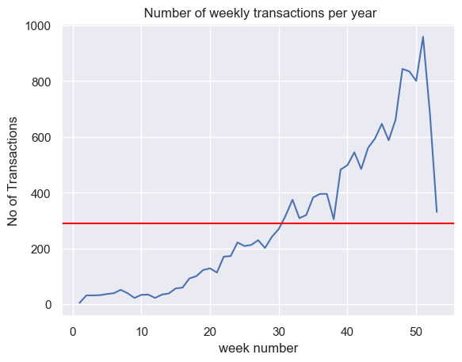

The graph reveals that:

1. There was an upward transactions over the year.
2. Most transactions took place in the second half of the year.
3. There is a spike in transactions at the end of the year which could be the cause of increased processing times

## Recommendations

Based on the results and findings I make the following recommendations:

1. Focus marketing and sales efforts in the Retail Industry especially in the cities of Cape Town and Johannesburg as they have the highest Customer Lifetime Value.
2. Offer incentives to retail customers to encourage frequent transactions e.g. Reduced transaction charges could be implemented for retail businesses who transact frequently.
3. Increase technology resources and manpower towards the end of the year(November-Dember) to handle the spike of transactions during this period. This will reduce the transaction processing times which at times could unsettle customers and cause distrust.